# lawson_assignment_01_final

# **An Analysis of Trends in Baltimore’s 16-19-year-old teens**

## Harper Lawson

### Background

The data utilized in this notebook is from the Vital Signs Open Data Portal. The source is the American Community Survey, a yearly demographics survey administered by the U.S. Census Bureau. The title of the spreadsheet online is “Percentage of Population aged 16-19 in School and/or Employed.”

It collects data from 2010-2020. It is worth noting that the boundaries of certain neighborhoods underwent small changes before the data was collected in 2020, which is why there is a separate column with updated neighborhood names for 2020.

It can be inferred that if teenagers are neither enrolled in school or working a job, that their financial situation is not ideal. This is why this data is a fair representation of wealth inequality in Baltimore, as the neighborhoods have varying statistics.

The online data can be found [here](https://vital-signs-bniajfi.hub.arcgis.com/maps/7d814d51552b45e2bfe17e4edf417131/about).

### Process

To load the necessary packages:

```r
library (tidyverse)
library (rmarkdown)
library (janitor)
library (ggplot2)
library (ggthemes)
library (dplyr)

# Assuming these packages are already installed.
# Assuming base, datasets, forcats, graphics, purrr, readr, and stats are already installed and loaded.
```

To load the necessary data:

```r
balt_pop <- read_csv("balt_pop_16_19.csv")
```

For each year, the values below are the percent of 16-19-year-olds in Baltimore who are either enrolled in school or employed.

#### Question 1:

**A)** Which 5 communities in Baltimore experienced the highest growth of 16-19 year olds who were either employed or enrolled in school? What was the percent change of each?

To make a new data frame with growth info:

```r
growth <- balt_pop %>%
  select(Place_1, Place_2, x2010, x2020) %>%
  mutate(pct_change = round(((x2020-x2010)/x2010)*100, 2))
```

To calculate the 5 communities with the highest growth and create a table:

```r
top_5_growth <- growth %>%
  select(Place_1, pct_change) %>%
  slice_max(pct_change, n=5)

top_5_growth
```

| Place_1 | pct_change |
| --- | --- |
| South Baltimore | 108.70 |
| Dorchester/Ashburton | 36.87 |
| Greater Mondawmin | 27.89 |
| Edmondson Village | 23.27 |
| Chinquapin Park/Belvedere | 22.63 |

```r
NA
```

Let’s visualize this.

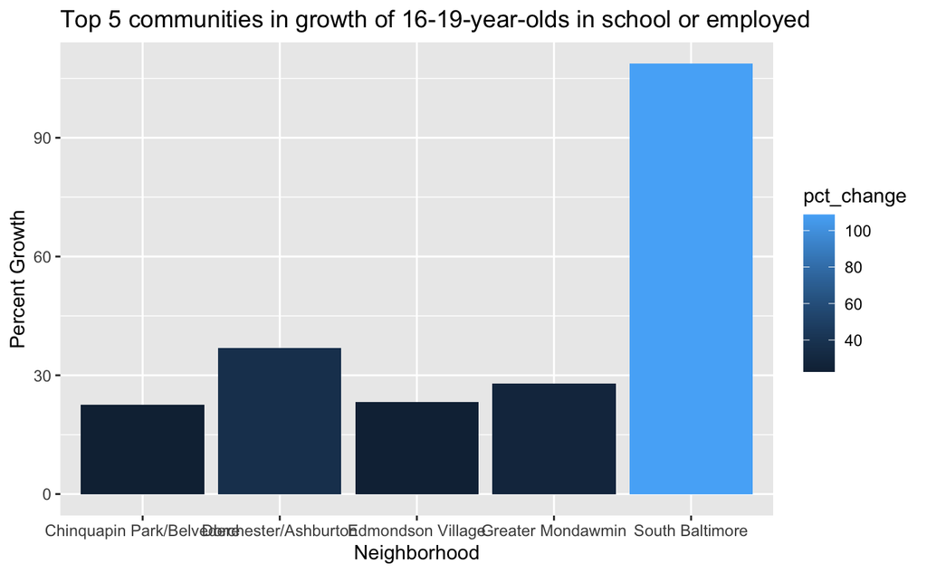

```r
top_5_growth %>%
  select(Place_1, pct_change) %>%
  ggplot() +
  geom_bar(aes(x = Place_1, y = pct_change, fill = pct_change), stat = "identity") +
  labs(x = "Neighborhood", y = "Percent Growth", title = "Top 5 communities in growth of 16-19-year-olds in school or employed")
```

**B)** South Baltimore had the highest growth by a landslide. What percentage of 16-19-year-olds were in school or employed in 2010? 2015? 2020?

```r
south_balt <- subset(balt_pop, Place_1 == "South Baltimore")

south_balt %>%
select(Place_1, x2010, x2015, x2020)
```

| Place_1 | x2010 | x2015 | x2020 |
| --- | --- | --- | --- |
| South Baltimore | 47.91667 | 98.48485 | 100 |

```r
NA
```

By looking at my new south_balt table, I can see that 47.92% of 16-19-year-olds were in school or employed in 2010, 98.48% in 2015, and 100.00% in 2020. Let’s see what the overall growth looks like.

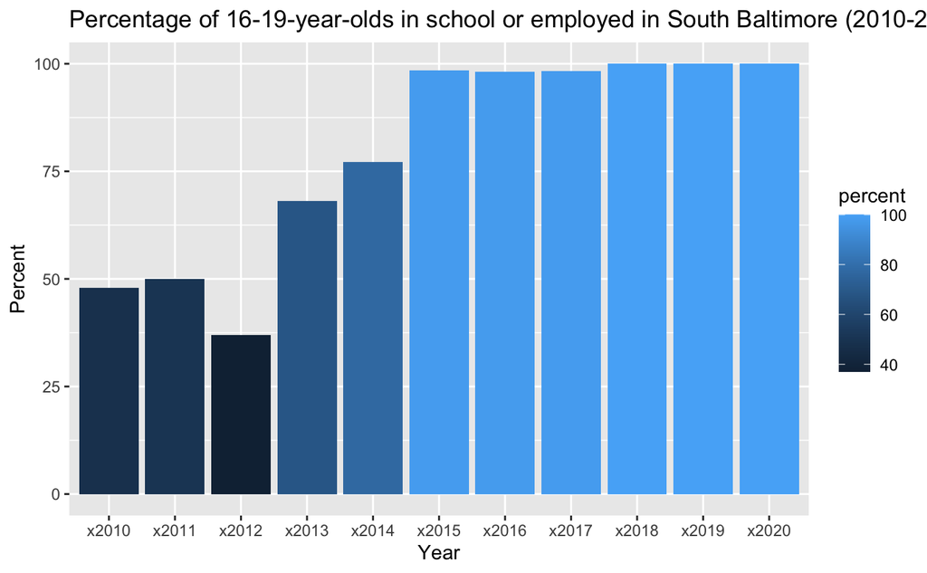

```r
south_balt %>%
  select(x2010, x2011, x2012, x2013, x2014, x2015, x2016, x2017, x2018, x2019, x2020) %>%
  gather(key = "year", value = "percent", x2010:x2020) %>%
  ggplot() +
  geom_bar(aes(x = year, y = percent, fill = percent), stat = "identity") +
  labs(x = "Year", y = "Percent", title = "Percentage of 16-19-year-olds in school or employed in South Baltimore (2010-2020)")
```

```r
NA
NA
NA
```

Looking at the chart, was this growth gradual, or did it happen quickly over a short time period?

#### Question 2:

Which one-year period showed the highest growth in South Baltimore?

```r
south_balt <- south_balt %>%
  mutate(pct_change_2010_2011 = round(((x2011-x2010)/x2010)*100, 2)) %>%
  mutate(pct_change_2011_2012 = round(((x2012-x2011)/x2011)*100, 2)) %>%
  mutate(pct_change_2012_2013 = round(((x2013-x2012)/x2012)*100, 2)) %>%
  mutate(pct_change_2013_2014 = round(((x2014-x2013)/x2013)*100, 2)) %>%
  mutate(pct_change_2014_2015 = round(((x2015-x2014)/x2014)*100, 2)) %>%
  mutate(pct_change_2015_2016 = round(((x2016-x2015)/x2015)*100, 2)) %>%
  mutate(pct_change_2016_2017 = round(((x2017-x2016)/x2016)*100, 2)) %>%
  mutate(pct_change_2017_2018 = round(((x2018-x2017)/x2017)*100, 2)) %>%
  mutate(pct_change_2018_2019 = round(((x2019-x2018)/x2018)*100, 2)) %>%
  mutate(pct_change_2019_2020 = round(((x2020-x2019)/x2019)*100, 2))

south_balt %>%
  select(pct_change_2010_2011, pct_change_2011_2012, pct_change_2012_2013, pct_change_2013_2014, pct_change_2014_2015, pct_change_2015_2016, pct_change_2016_2017, pct_change_2017_2018, pct_change_2018_2019, pct_change_2019_2020)
```

| pct_change_2010_2011 | pct_change_2011_2012 | pct_change_2012_2013 | pct_change_2013_2014 | pct_change_2014_2015 | pct_change_2015_2016 | pct_change_2016_2017 | pct_change_2017_2018 | pct_change_2018_2019 | pct_change_2019_2020 |
| --- | --- | --- | --- | --- | --- | --- | --- | --- | --- |
| 4.35 | -25.93 | 83.83 | 13.38 | 27.58 | -0.31 | 0.13 | 1.72 | 0 | 0 |

```r
NA
```

As we can see from this table, 2012-2013 experienced the highest growth of 16-19-year-olds in school or employed at 83.83%.

#### Question 3:

**A)** Looking at the south_balt table, when was the percentage of 16-19-year-olds in school or employed in South Baltimore at or below 50%?

```r
south_balt1 <- south_balt %>%
  select(Place_1, x2010, x2011, x2012, x2013, x2014, x2015, x2016, x2017, x2018, x2019, x2020) %>%
  pivot_longer(names_to="year",
               values_to="percent",
               cols =2:10) %>%
  select(Place_1, year, percent)

south_balt1 %>%
  filter(percent <= 50)
```

| Place_1 | year | percent |
| --- | --- | --- |
| South Baltimore | x2010 | 47.91667 |
| South Baltimore | x2011 | 50.00000 |
| South Baltimore | x2012 | 37.03704 |

```r
NA
```

We can see from this table that the percentage of 16-19-year-olds in school or employed in South Baltimore was at or below 50% in 2010, 2011, and 2012.

**B)** How do these values compare to Baltimore’s averages during these years?

First, I will organize the mean values of 2010, 2011, and 2012.

```r
  balt_means <- colMeans(select(balt_pop, x2010, x2011, x2012), na.rm = TRUE)
  tibble(Year = c("x2010", "x2011", "x2012"), Mean = balt_means)
```

| Year | Mean |
| --- | --- |
| x2010 | 84.72963 |
| x2011 | 85.29870 |
| x2012 | 86.00339 |

```r
NA
```

Now, I will look at the South Baltimore values again on their own…

```r
south_balt %>%
  select(x2010, x2011, x2012)
```

| x2010 | x2011 | x2012 |
| --- | --- | --- |
| 47.91667 | 50 | 37.03704 |

```r
NA
```

…assign their values and the mean values…

```r
#2010
south_balt_2010 <- 47.92
mean_2010 <- 84.73

#2011
south_balt_2011 <- 50.00
mean_2011 <- 85.30

#2012
south_balt_2012 <- 37.04
mean_2012 <- 86.00
```

…and do some subtraction (mean value minus South Baltimore value of the same year).

```r
mean_2010-south_balt_2010
```

```
[1] 36.81
```

```r
mean_2011-south_balt_2011
```

```
[1] 35.3
```

```r
mean_2012-south_balt_2012
```

```
[1] 48.96
```

And now we see how far South Baltimore’s 2010-12 percentages were below Baltimore’s mean values.

### Conclusion

2010-2012 was a major low point for the community of South Baltimore compared to Baltimore as a whole in terms of how many 16-19-year-olds were in school or employed. On the other hand, 2013-2015 showed amazing growth.

### Reporting Memo/Story Pitch

The most newsworthy story found in this data analysis is the growth in the percentage of 16-19-year-olds in school or employed in South Baltimore from 2010 to 2015.

So why is this important?

Based on the analyzed data, a major event had to have occurred in South Baltimore from 2010 to 2014 involving the neighborhood’s 16-19-year-old population. Such low rates of young adults enrolled in school or holding a job seems pretty alarming and definitely worth looking into.

On the other hand, another dramatic change or event was likely necessary to inspire growth in this area to the extent that we can see.

Why were so many 16-19-year-olds in South Baltimore neither in school nor employed from 2010 to 2012 (arguably from 2012 to 2014 as well), and what inspired the major growth we saw by 2015?

To find this out, I would need to cross-reference this data with other information from agencies like the U.S. Census Bureau or Baltimore County Public Schools. I could research factors like high school drop-out rates, the employment rate of high school-aged individuals, reported violent crimes within high schools, and drug usage rates among this age group as well.

By compiling, cross-referencing and analyzing these resources, I could hope to get to the bottom of this anomaly in South Baltimore.

### Tweet Drafts

@htlawson8: Data shows that South Baltimore experienced the largest increase in youth in school or employed compared to other Baltimore neighborhoods. Check it out among the five neighborhoods with the highest growth:

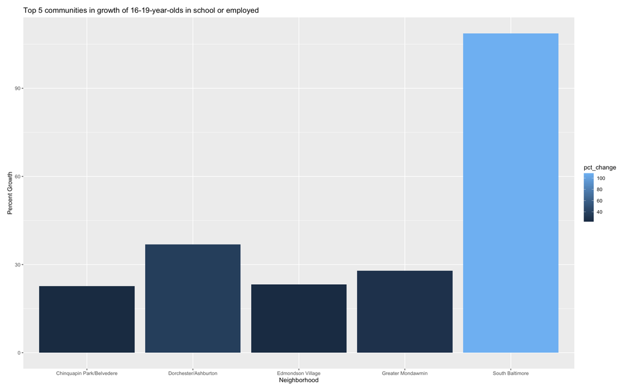

@htlawson8: Take a look at South Baltimore’s growth in its percentage of 16-19-year-olds in school or employed:

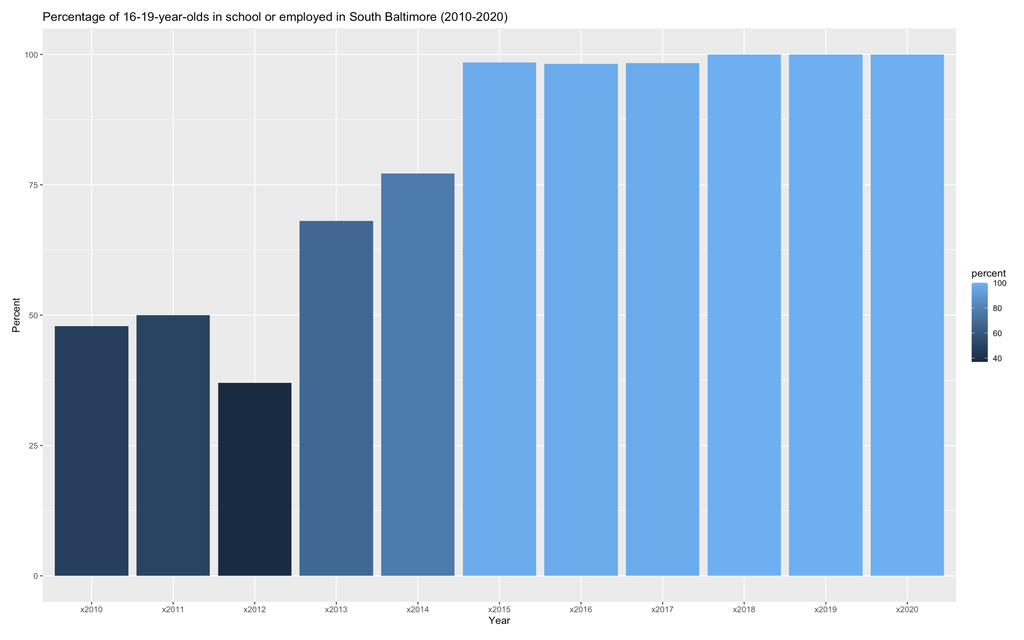